# MissingMigrants_1

Кузнецов Вячеслав, БЛГ-182 В полученном файле содержались данные о мигрантах, умерших или пропавших без вести на территории другой чужой страны. Основной целью работы является выявление основных критериев человека, чья жизнь потенциально находится под угрозой после того, как он пересек границу. По результатам проделанной работы были можно сформулировать следующее описание человека, чья жизнь потенциально находится под угрозой: 1) Покинул(-а) Африку; 2) Пересекает Средиземное Море; 3) Пребывает на территории/границе США и Мексики. Описание набора данных: csv файл, данные разделены запятой, содержит информацию о случаях пропажи людей без вести.

Загружаем в питон необходимые для анализа библиотеки.

```python
import pandas as pd
import numpy as np
import matplotlib.pyplot as plt
import seaborn as sns
```

Загружаем файл и меняем кодировку из-за возникновения ошибок при чтении файла.

```python
migrants = pd.read_csv('MissingMigrantsProject.csv', encoding = 'latin-1')
```

Проводим первичный осмотр данных, сразу видны пропущенные значения.

```python
migrants
```

|  | id | cause_of_death | region_origin | affected_nationality | missing | dead | incident_region | date | source | reliability | lat | lon |
| --- | --- | --- | --- | --- | --- | --- | --- | --- | --- | --- | --- | --- |
| 0 | 1 | Presumed drowning | Middle East | Iraq | 1.0 | 1.0 | Mediterranean | 05/11/2015 | IOM Greece | Verified | 36.891500 | 27.287700 |
| 1 | 3 | Fell from train | Central America & Mexico | Honduras | NaN | 1.0 | Central America incl. Mexico | 03/11/2015 | La Jornada | Partially Verified | 15.956400 | -93.663100 |
| 2 | 4 | Presumed drowning | Middle East | NaN | NaN | 1.0 | Mediterranean | 03/11/2015 | Hellenic Coast Guard | Verified | 36.504390 | 27.363253 |
| 3 | 6 | Drowning | MENA | NaN | 6.0 | 4.0 | Mediterranean | 01/11/2015 | Reuters | Partially Verified | 37.285600 | 27.086600 |
| 4 | 7 | Vehicle accident | South East Asia | Cambodia | NaN | 4.0 | Southeast Asia | 01/11/2015 | Phnom Penh Post | Partially Verified | 13.361100 | 100.985000 |
| ... | ... | ... | ... | ... | ... | ... | ... | ... | ... | ... | ... | ... |
| 2415 | 184746 | Drowning | Central America & Mexico | NaN | NaN | 1.0 | U.S./Mexico Border | 20/05/2017 | Líder Informativo | Partially Verified | 27.455267 | -99.493386 |
| 2416 | 184747 | Train accident | Central America & Mexico | Honduras | NaN | 1.0 | U.S./Mexico Border | 26/05/2017 | netnoticias.mx | Partially Verified | 28.712901 | -100.497975 |
| 2417 | 184748 | NaN | Central America & Mexico | Honduras | NaN | 1.0 | U.S./Mexico Border | 27/05/2017 | Águilas del Desierto | Partially Verified | 32.304420 | -112.904651 |
| 2418 | 184749 | Train accident | Central America & Mexico | NaN | NaN | 1.0 | Central America incl. Mexico | 29/05/2017 | Zócalo | Partially Verified | 26.777611 | -101.429548 |
| 2419 | 184750 | Dehydration | Sub-Saharan Africa | Ghana, Nigeria | NaN | 44.0 | North Africa | 31/05/2017 | IOM Niger | Verified | 18.917266 | 12.477509 |

2420 rows × 12 columns

Проверяем файл на наличие дубликатов и анализируем пустые значения.

```python
migrants.isnull().sum()
```

```
id                         0
cause_of_death           203
region_origin            443
affected_nationality    1575
missing                 2149
dead                     102
incident_region           10
date                       9
source                     7
reliability              324
lat                        4
lon                        4
dtype: int64
```

```python
migrants.duplicated().sum()
```

```
0
```

Дубликатов выявлено не было, пустые значения присутствуют в каждом столбце, за исключением id.

Самое большое количество пустых значений было обнаружено в столбцах affected_nationality и missing. Было принято решение убрать первый из рассматриваемых столбцов, по причине невозможности установить или как-либо заменить значения в этом столбце.

```python
migrants = migrants.drop(columns = ['affected_nationality'])
```

Иследовав данные столбцов missing и dead, было допущено, что в пропусках должны стоять нули. (если есть данные о количестве мертвых, но нет о пропавших - пропавшие отсутствуют; и наоборот) Выведя все возможные варианты значений столбца reliability было допущено, что вместо пропущенных значений должно стоять Unverified. (раз данных о них нет, значит подтверждений им тоже нет) Значения Partially verified в этом же столбце были заменены на Partially Verified для более корректного отображения информации. Пустые значения в столбцах cause_of_death и region_origin были заполнены Unknown, поскольку никакой возможности установить их нет.

```python
migrants['missing'] = migrants['missing'].fillna(0)
migrants['dead'] = migrants['dead'].fillna(0)
migrants['reliability'] = migrants['reliability'].fillna('Unverified')
migrants.loc[migrants['reliability'] == 'Partially verified', 'reliability'] = 'Partially Verified'
migrants['cause_of_death'] = migrants['cause_of_death'].fillna('Unknown')
migrants['region_origin'] = migrants['region_origin'].fillna('Unknown')
```

Ищем пустые значения в столбце incident_region.

```python
migrants[migrants['incident_region'].isnull()]
```

|  | id | cause_of_death | region_origin | missing | dead | incident_region | date | source | reliability | lat | lon |
| --- | --- | --- | --- | --- | --- | --- | --- | --- | --- | --- | --- |
| 331 | 397 | Shot | South Asia | 0.0 | 1.0 | NaN | 26/02/2014 | Daily Star | Verified | 25.184100 | 88.905500 |
| 459 | 4566 | Unknown | Unknown | 0.0 | 0.0 | NaN | NaN | NaN | Unverified | 33.516932 | 15.358276 |
| 488 | 14564 | Unknown | MENA | 3.0 | 2.0 | NaN | NaN | Hurriyet Daily News | Unverified | 36.181909 | 29.617136 |
| 539 | 19778 | Unknown | MENA | 0.0 | 1.0 | NaN | NaN | Hellenic Coast Guard | Unverified | 38.329008 | 26.145186 |
| 593 | 27375 | Unknown | Central America | 0.0 | 4.0 | NaN | NaN | Noticiero de San Vicente | Unverified | 23.999999 | -98.749999 |
| 639 | 37377 | Unknown | Unknown | 0.0 | 0.0 | NaN | NaN | NaN | Unverified | 32.191256 | 30.972891 |
| 1132 | 111777 | Unknown | Unknown | 0.0 | 0.0 | NaN | NaN | NaN | Unverified | 24.063343 | 29.830313 |
| 1133 | 111778 | Unknown | Unknown | 0.0 | 0.0 | NaN | NaN | NaN | Unverified | 48.178412 | 11.812734 |
| 1134 | 111779 | Unknown | Unknown | 0.0 | 0.0 | NaN | NaN | NaN | Unverified | 35.260713 | 51.011953 |
| 1213 | 122177 | Unknown | Unknown | 0.0 | 0.0 | NaN | NaN | NaN | Unverified | 39.272424 | 26.429449 |

```python
migrants = migrants.drop(labels=[459, 639, 1132, 1133, 1134, 1213], axis=0)
migrants[migrants['incident_region'].isnull()]
```

|  | id | cause_of_death | region_origin | missing | dead | incident_region | date | source | reliability | lat | lon |
| --- | --- | --- | --- | --- | --- | --- | --- | --- | --- | --- | --- |
| 331 | 397 | Shot | South Asia | 0.0 | 1.0 | NaN | 26/02/2014 | Daily Star | Verified | 25.184100 | 88.905500 |
| 488 | 14564 | Unknown | MENA | 3.0 | 2.0 | NaN | NaN | Hurriyet Daily News | Unverified | 36.181909 | 29.617136 |
| 539 | 19778 | Unknown | MENA | 0.0 | 1.0 | NaN | NaN | Hellenic Coast Guard | Unverified | 38.329008 | 26.145186 |
| 593 | 27375 | Unknown | Central America | 0.0 | 4.0 | NaN | NaN | Noticiero de San Vicente | Unverified | 23.999999 | -98.749999 |

Руководствуясь вариантами из столбцов lat и lon, определяем возможные значения столбца incident region исходя из предложенных вариантов с помощью гугл карт.

```python
migrants.loc[migrants['id'] == 397, 'incident_region'] =  'Southeast Asia'
migrants.loc[migrants['id'] == 14564, 'incident_region'] =  'Mediterranean'
migrants.loc[migrants['id'] == 19778, 'incident_region'] =  'Europe'
migrants.loc[migrants['id'] == 27375, 'incident_region'] =  'Central America & Mexico'
```

Координаты нам больше не нужны, удаляем столбцы.

```python
migrants = migrants.drop(columns = ['lat'])
migrants = migrants.drop(columns = ['lon'])
```

Исправляем расхождения в названиях регионов в столбцах и объединяем Horn of Africa (P) с Horn of Africa.

```python
migrants.loc[migrants['region_origin'] == 'Central America', 'region_origin'] = 'Central America & Mexico'
migrants.loc[migrants['region_origin'] == 'Horn of Africa (P)', 'region_origin'] = 'Horn of Africa'
migrants.loc[migrants['incident_region'] == 'Central America incl. Mexico', 'incident_region'] = 'Central America & Mexico'
```

Анализируем пропуски в столбце date, заполняем их ближайшими датами по номеру id. Данное действие не является критичным, поскольку впоследствии нам будет важен только год и месяц.

```python
migrants.loc[migrants['id'] == 14564, 'date'] =  '11/12/2015'
migrants.loc[migrants['id'] == 19778, 'date'] =  '17/12/2015'
migrants.loc[migrants['id'] == 27375, 'date'] =  '20/11/2015'
```

Источник информации нам так же определить не удастся, заменяем оставшееся пустое значение в столбце source на Unknown

```python
migrants.loc[migrants['id'] == 182347, 'source'] =  'Unknown'
```

После всех проведенных преобразований получаем следующий результат по пропускам:

```python
migrants.isnull().sum()
```

```
id                 0
cause_of_death     0
region_origin      0
missing            0
dead               0
incident_region    0
date               0
source             0
reliability        0
dtype: int64
```

Добавим два новых столбца в фрейм для визуализации.

```python
migrants['date'] = pd.to_datetime(migrants['date'])
migrants['year'], migrants['month'] = migrants['date'].dt.year, migrants['date'].dt.month
migrants
```

|  | id | cause_of_death | region_origin | missing | dead | incident_region | date | source | reliability | year | month |
| --- | --- | --- | --- | --- | --- | --- | --- | --- | --- | --- | --- |
| 0 | 1 | Presumed drowning | Middle East | 1.0 | 1.0 | Mediterranean | 2015-05-11 | IOM Greece | Verified | 2015 | 5 |
| 1 | 3 | Fell from train | Central America & Mexico | 0.0 | 1.0 | Central America & Mexico | 2015-03-11 | La Jornada | Partially Verified | 2015 | 3 |
| 2 | 4 | Presumed drowning | Middle East | 0.0 | 1.0 | Mediterranean | 2015-03-11 | Hellenic Coast Guard | Verified | 2015 | 3 |
| 3 | 6 | Drowning | MENA | 6.0 | 4.0 | Mediterranean | 2015-01-11 | Reuters | Partially Verified | 2015 | 1 |
| 4 | 7 | Vehicle accident | South East Asia | 0.0 | 4.0 | Southeast Asia | 2015-01-11 | Phnom Penh Post | Partially Verified | 2015 | 1 |
| ... | ... | ... | ... | ... | ... | ... | ... | ... | ... | ... | ... |
| 2415 | 184746 | Drowning | Central America & Mexico | 0.0 | 1.0 | U.S./Mexico Border | 2017-05-20 | Líder Informativo | Partially Verified | 2017 | 5 |
| 2416 | 184747 | Train accident | Central America & Mexico | 0.0 | 1.0 | U.S./Mexico Border | 2017-05-26 | netnoticias.mx | Partially Verified | 2017 | 5 |
| 2417 | 184748 | Unknown | Central America & Mexico | 0.0 | 1.0 | U.S./Mexico Border | 2017-05-27 | Águilas del Desierto | Partially Verified | 2017 | 5 |
| 2418 | 184749 | Train accident | Central America & Mexico | 0.0 | 1.0 | Central America & Mexico | 2017-05-29 | Zócalo | Partially Verified | 2017 | 5 |
| 2419 | 184750 | Dehydration | Sub-Saharan Africa | 0.0 | 44.0 | North Africa | 2017-05-31 | IOM Niger | Verified | 2017 | 5 |

2414 rows × 11 columns

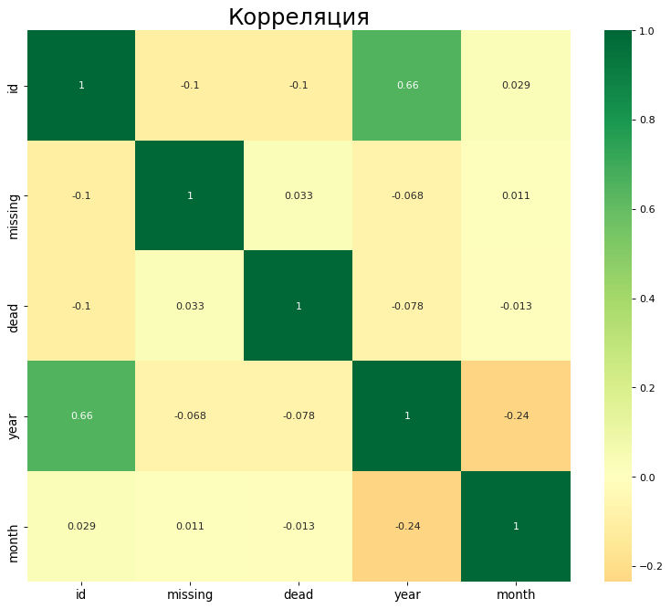

```python
# Plot
plt.figure(figsize=(12,10), dpi= 80)
sns.heatmap(migrants.corr(), xticklabels=migrants.corr().columns, yticklabels=migrants.corr().columns, cmap='RdYlGn', center=0, annot=True)

# Decorations
plt.title('Корреляция', fontsize=22)
plt.xticks(fontsize=12)
plt.yticks(fontsize=12)
plt.show()
```

Наиболее выраженная зависимость прослеживается между id и year.

```python
mig_g = migrants.groupby('year')['id'].count()
mig_g
```

```
year
2014     244
2015     630
2016    1222
2017     318
Name: id, dtype: int64
```

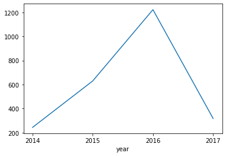

```python
mig_g.plot(xticks = mig_g.index)
```

Наибольшее количество инцидентов было выявлено в 2016 году.

```python
mig_g1 = migrants.groupby('month')['id'].count()
mig_g1
```

```
month
1     247
2     185
3     205
4     159
5     179
6     170
7     203
8     175
9     189
10    263
11    183
12    256
Name: id, dtype: int64
```

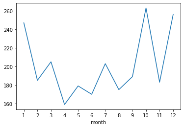

```python
mig_g1.plot(xticks = mig_g1.index)
```

```python
inc_g = migrants.groupby('incident_region', as_index = False)[['missing', 'dead']].sum()
inc_g
```

|  | incident_region | missing | dead |
| --- | --- | --- | --- |
| 0 | Caribbean | 212.0 | 111.0 |
| 1 | Central America & Mexico | 0.0 | 425.0 |
| 2 | East Asia | 17.0 | 2.0 |
| 3 | Europe | 0.0 | 231.0 |
| 4 | Horn of Africa | 172.0 | 512.0 |
| 5 | Mediterranean | 8992.0 | 4828.0 |
| 6 | Middle East | 0.0 | 49.0 |
| 7 | Middle East | 11.0 | 141.0 |
| 8 | North Africa | 275.0 | 2257.0 |
| 9 | North America | 0.0 | 1.0 |
| 10 | South America | 0.0 | 35.0 |
| 11 | Southeast Asia | 1032.0 | 808.0 |
| 12 | Sub-Saharan Africa | 31.0 | 426.0 |
| 13 | U.S./Mexico Border | 5.0 | 1136.0 |

```python
ori_g = migrants.groupby('region_origin', as_index = False)[['missing', 'dead']].sum()
ori_g
```

|  | region_origin | missing | dead |
| --- | --- | --- | --- |
| 0 | Caribbean | 178.0 | 131.0 |
| 1 | Central America & Mexico | 5.0 | 1408.0 |
| 2 | East Asia | 24.0 | 5.0 |
| 3 | Horn of Africa | 477.0 | 2393.0 |
| 4 | MENA | 1470.0 | 1109.0 |
| 5 | Middle East | 36.0 | 104.0 |
| 6 | Middle East/ South Asia | 60.0 | 198.0 |
| 7 | Mixed | 2314.0 | 447.0 |
| 8 | North Africa | 3.0 | 14.0 |
| 9 | South America | 19.0 | 22.0 |
| 10 | South Asia | 28.0 | 201.0 |
| 11 | South East Asia | 1040.0 | 762.0 |
| 12 | Southern Europe | 0.0 | 1.0 |
| 13 | Sub-Saharan Africa | 2290.0 | 1378.0 |
| 14 | Unknown | 2803.0 | 2789.0 |

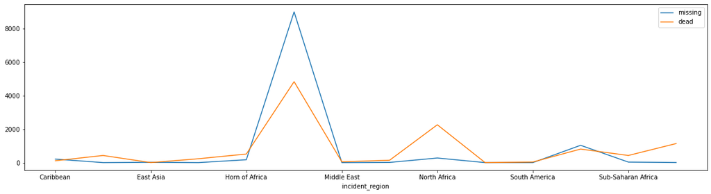

```python
plt.rcParams['figure.figsize'] = [20, 5]
inc_g.plot.line(x= 'incident_region', y=['missing', 'dead'])
```

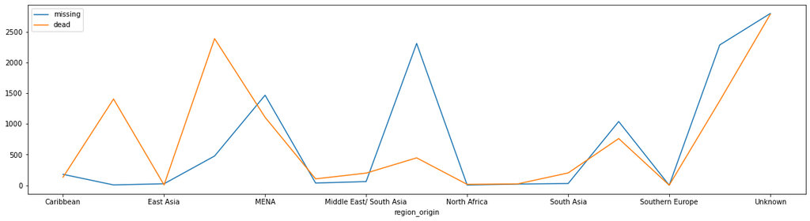

```python
plt.rcParams['figure.figsize'] = [20, 5]
ori_g.plot.line(x= 'region_origin', y=['missing', 'dead'])
```

Основная масса пропаж и смертей произошла в регионе Средиземное Море, при этом большая часть пропавших или умерших, за исключением неизвестных, - изначально покинули Африку.

Причин смерти слишком много для адекватной оценки, поэтому попробуем построить диаграмму на основании только 10 наиболее частых причин смертей:

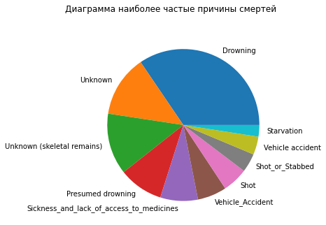

```python
plt.suptitle('Диаграмма наиболее частые причины смертей')
plt.rcParams['figure.figsize'] = [5, 5]

migrants['cause_of_death'].value_counts()[:10].plot.pie( y = migrants['cause_of_death'])
plt.ylabel("")
plt.show()
```

Выясним самую частую причину смерти в 2016 году, ей оказалась Drowning.

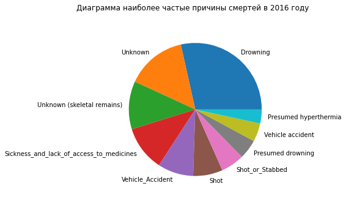

```python
plt.suptitle('Диаграмма наиболее частые причины смертей в 2016 году')
plt.rcParams['figure.figsize'] = [5, 5]

subset = migrants[migrants['year'] == 2016]

subset['cause_of_death'].value_counts()[:10].plot.pie( y = subset['cause_of_death'])
plt.ylabel("")
plt.show()
```

Теперь проанализируем, в каких регионах чаще всего происходят происшествия, ведущие к смерти:

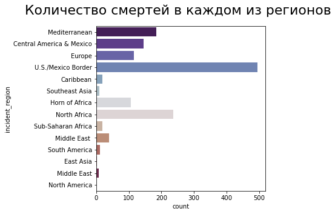

```python
plt.suptitle('Количество смертей в каждом из регионов', fontsize = 22)
plt.rcParams['figure.figsize'] = [30, 10]
subset = migrants[migrants['dead'] == 1]
sns.countplot( y='incident_region', data=subset, palette = 'twilight_shifted')
plt.show()
```

Так же рассмотрим, в каких регионах причиной смерти чаще всего служит стрельба:

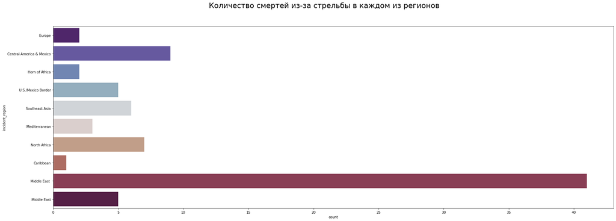

```python
plt.suptitle('Количество смертей из-за стрельбы в каждом из регионов', fontsize = 22)
plt.rcParams['figure.figsize'] = [30, 10]
subset = migrants[migrants['cause_of_death'] == 'Shot']
sns.countplot( y='incident_region', data=subset, palette = 'twilight_shifted')
plt.show()
```

Составим топ 10 газет, которые чаще всего предоставляют непроверенную информацию:

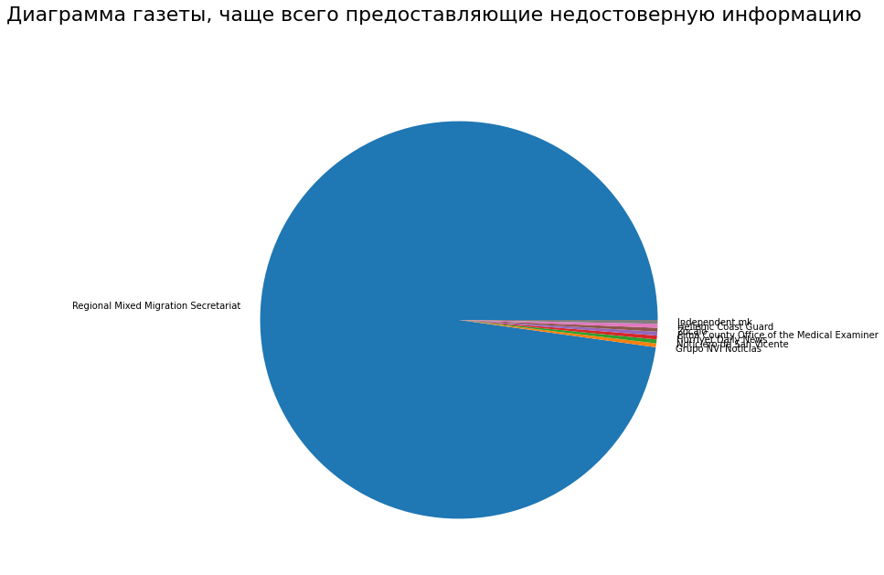

```python
plt.suptitle('Диаграмма газеты, чаще всего предоставляющие недостоверную информацию', fontsize = 22)
plt.rcParams['figure.figsize'] = [20, 20]

subset = migrants[migrants['reliability'] == "Unverified"]
subset['source'].value_counts()[:10].plot.pie( y = subset['source'])
plt.ylabel("")
plt.show()
```

Газета, в которой чаще всего публикуется недостоверная информация, - Regional Mixed Migration Secretariat.